# Analyzing Customer Service for ABC Inc.

Analysis by Animish Andraskar

In this analysis, we are trying to find out answers to some questions that would help ABC Inc. understand the characteristics of customer service they provide, and know the key areas of improvement.

The data provided for this assignment is a sanitized subset of an actual customer service data. The purpose of this assignment was to answer some preset and some additional questions through exploratory data analysis.

The data has following columns:

- asst_id: Unique identifier of an asset
- product_type: Category of the asset
- mnfture_wk: Year and week in which the asset was manufactured
- contract_st: Year and week when the contract (warranty service from ABC Inc.) started
- contract_end: Year and week when the contract ended
- contact_wk: Year and week when customer contacted ABC's service center
- contact_type: Mode of contact used by the customer
- issue_type: Issue defined by the customer
- topic_category: Issue identified by the agent
- parts_sent: Names of the parts sent when the customer contacted for the first time
- parts_ct: Number of parts sent on first contact
- repair_type: Whether the repair needed hardware (hard) or software (soft) to fix the issue. In case both, it is categorized as hard.
- repeat_parts_sent: Names of the parts sent when the customer contacted again for the same issue
- repeat_ct: Number of parts sent when the customer contacted again for the same issue
- agent_tenure_indays: Tenure of the agent who handled the request (in days)
- contact_manager_flg: Flag whether agent needed help from his/her manager
- diagnostics: Company's internal diagnostics measures used by the agent
- region: Region of the asset sale (not necessarily the current customer location)
- country: Country of the asset sale (not necessarily the current customer location)

## 0. Import essential libraries

```python
from IPython.display import HTML

# Reference: https://stackoverflow.com/questions/27934885/how-to-hide-code-from-cells-in-ipython-notebook-visualized-with-nbviewer
HTML('''<script>
code_show=true;
function code_toggle() {
 if (code_show){
 $('div.input').hide();
 } else {
 $('div.input').show();
 }
 code_show = !code_show
}
$( document ).ready(code_toggle);
</script>
<form action="javascript:code_toggle()">
<input type="submit" value="Click here to toggle on/off the raw code.">
</form>''')
```

```python
import pandas as pd
import numpy as np
import matplotlib.pyplot as plt
import seaborn as sns
from scipy import stats
from scipy.stats import chi2_contingency
from scipy.stats import chi2
import re

import warnings
warnings.filterwarnings('ignore')
SEED = 0
```

## 1. Data reading

### 1.1 Read csv file

```python
data = pd.read_csv("Sample_Service_data.csv")
data.head()
```

|  | asst_id | product_type | mnfture_wk | contract_st | contract_end | contact_wk | contact_type | issue_type | topic_category | parts_sent | repair_type | repeat_ct | parts_ct | agent_tenure_indays | contact_manager_flg | diagnostics | repeat_parts_sent | region | country |
| --- | --- | --- | --- | --- | --- | --- | --- | --- | --- | --- | --- | --- | --- | --- | --- | --- | --- | --- | --- |
| 0 | 0 | Laptops | 201726 | 201726 | 202125 | 201840 | Voice | NaN | NaN | Hard Drive, Documentation(2) | Hard | 0 | 3 | 1018.0 | 0 | Not_USED | NaN | Hogwarts | NaN |
| 1 | 1 | Laptops | 201650 | 201650 | 201949 | 201840 | Voice | NaN | NaN | Speaker, Chassis | Hard | 0 | 2 | 1018.0 | 0 | Not_USED | NaN | Hogwarts | Zonko's Joke Shop |
| 2 | 2 | Laptops | 201821 | 201821 | 202222 | 201840 | Voice | NaN | NaN | Cables | Hard | 0 | 1 | 1018.0 | 0 | Not_USED | Motherboard, Miscellaneous(2), Hard Drive, Cha... | Hogwarts | Zonko's Joke Shop |
| 3 | 3 | Laptops | 201608 | 201608 | 201908 | 201840 | VOICE | Hard Drive | Booting | Hard Drive | Hard | 0 | 1 | 298.0 | 0 | Effective_Usage | NaN | Hogwarts | Zonko's Joke Shop |
| 4 | 4 | Laptops | 201732 | 201732 | 202032 | 201840 | Voice | NaN | NaN | Battery (Notebook) | Hard | 0 | 1 | 1018.0 | 0 | Not_USED | NaN | Hogwarts | Zonko's Joke Shop |

#### Understand data shape (rows and columns) and column names

```python
print('Data shape:', data.shape)
print('Column names:', data.columns)
```

```
Data shape: (100000, 19)
Column names: Index(['asst_id', 'product_type', 'mnfture_wk', 'contract_st', 'contract_end',
       'contact_wk', 'contact_type', 'issue_type', 'topic_category',
       'parts_sent', 'repair_type', 'repeat_ct', 'parts_ct',
       'agent_tenure_indays', 'contact_manager_flg', 'diagnostics',
       'repeat_parts_sent', 'region', 'country'],
      dtype='object')
```

## 2. Data exploration

### 2.1 Data inspection

#### 2.1.0 Essential data treatment functions

```python
explore_data = data.copy()
```

```python
# created_value_counts keeps a track of new columns created while converting the table into 1NF
created_value_counts = {}
```

```python
def get_value_counts(string):
    """
    This function takes in a string and splits it on " ," to separate out atomic values in it.
    Then, it finds the count enclosed within parantheses.
    For example,
    if we have a string "Hard Drive, Documentation(2)", it will provide Hard Drive with count 1
    and Documentation with count 2.
    """
    # split string on " ,"
    st_split = str(string).split(", ")

    # empty list to hold value and count
    value_counts = []
    # set to hold unique values extracted
    values = set()

    # traverse each split element from the string
    for sts_split in st_split:
        # if the split part contains parantheses AND those parantheses include only numbers
        if sts_split.count("(") >= 1 and re.match("^[0-9)]*$", sts_split.rsplit('(', maxsplit=1)[1]):
            # split the string from right, so that we get 2 from strings like "Battery (Notebook)(2)"
            ssp_split = sts_split.rsplit('(', maxsplit=1)
            # remove spaces and convert to lowercase
            val = ssp_split[0].replace(" ", "").lower()
            # after trimming, if the value is null, skip
            # otherwise, note down the value and its count
            if val != "nan" and val != "":
                cnt = int(ssp_split[1].replace(")", ""))
                value_counts.append((val, cnt))
                values.add(val)
        # if no parantheses or only numbers inside parantheses, simply take the value and count is 1
        else:
            val = sts_split.replace(" ", "").lower()
            if val != "nan" and val != "":
                value_counts.append((val, 1))
                values.add(val)
    return values, value_counts
```

```python
def create_value_counts(col, suffix, create_new=True):
    """
    This function takes the column name to create new columns on and a suffix to add to those columns names.
    For example, if we are separating out values inside issue_type, we would pass the name as the first argument,
    and issue_ as the suffix.
    """
    # unique values, and value-count pairs to be returned by get_value_counts()
    values = set() # this will help us in creating new columns
    value_counts = [] # this will help us in adding the counts in those columns

    # traverse each row, split the string inside it to get the value and its count enclosed in parantheses
    for row in explore_data[col]:
        vals, value_ct = get_value_counts(row)
        # add value to our unique values set
        values.update(vals)
        # add value-count to the list
        value_counts.append(value_ct)

#     at this point, values should have all the unique split values
#     and value_counts should have elements equal to number of rows in the dataset

#        if we have three rows:
#             Miscellaneous(2)
#             Motherboard, Documentation(ABC)(2)
#             Motherboard, Documentation

#.       values will be a set of {"Miscellaneous", "Motherboard", "Documentation" and "Documentation(ABC)"}

#.       value_counts will have 3 sub-lists (one for each row):
#.             [
#                 [("Miscellaneous", 1)],
#                 [("Motherboard", 1), ("Documentation(ABC)", 2)],
#                 [("Motherboard", 1), ("Documentation", 1)]
#              ]

#       Documentation and Documentation(ABC) are treated different

    print("Total columns created:", len(values))

    # for each unique extracted value, create a new column in the data if the flag set to true
    if create_new:
        # first, create a list of column names with suffix for later use
        # then, create those columns with count "0"
        new_cols = []
        for val in values:
            new_cols.append(suffix + val)
            explore_data[suffix + val] = 0
        # store new column names in a dictionary
        created_value_counts[col] = new_cols

    # Update counts form value_counts
    for i, vc_all in enumerate(value_counts):
        for vc in vc_all: # traverse each value count pair in each row. Some rows may have no value counts (originally null)
            explore_data.loc[i, suffix + vc[0]] += vc[1]
```

#### 2.1.1 Data information

```python
explore_data.info()
```

```
<class 'pandas.core.frame.DataFrame'>
RangeIndex: 100000 entries, 0 to 99999
Data columns (total 19 columns):
 #   Column               Non-Null Count   Dtype
---  ------               --------------   -----
 0   asst_id              100000 non-null  int64
 1   product_type         99980 non-null   object
 2   mnfture_wk           100000 non-null  int64
 3   contract_st          100000 non-null  int64
 4   contract_end         100000 non-null  int64
 5   contact_wk           100000 non-null  int64
 6   contact_type         99986 non-null   object
 7   issue_type           85958 non-null   object
 8   topic_category       66916 non-null   object
 9   parts_sent           54566 non-null   object
 10  repair_type          100000 non-null  object
 11  repeat_ct            100000 non-null  int64
 12  parts_ct             100000 non-null  int64
 13  agent_tenure_indays  99986 non-null   float64
 14  contact_manager_flg  100000 non-null  int64
 15  diagnostics          100000 non-null  object
 16  repeat_parts_sent    13346 non-null   object
 17  region               99997 non-null   object
 18  country              89998 non-null   object
dtypes: float64(1), int64(8), object(10)
memory usage: 14.5+ MB
```

```python
total_rows = len(explore_data)
unique_rows = len(explore_data.drop_duplicates())
print("Total rows:", total_rows)
print("Unique rows:", unique_rows)
print("Duplicate rows:", total_rows-unique_rows)
```

```
Total rows: 100000
Unique rows: 86536
Duplicate rows: 13464
```

#### 2.1.2 Column distributions

```python
explore_data.describe()
```

|  | asst_id | mnfture_wk | contract_st | contract_end | contact_wk | repeat_ct | parts_ct | agent_tenure_indays | contact_manager_flg |
| --- | --- | --- | --- | --- | --- | --- | --- | --- | --- |
| count | 100000.000000 | 100000.000000 | 100000.000000 | 100000.000000 | 100000.0 | 100000.000000 | 100000.00000 | 99986.000000 | 100000.000000 |
| mean | 35702.117890 | 201672.108910 | 201671.595910 | 201951.897740 | 201840.0 | 0.074090 | 1.15955 | 985.886844 | 0.012430 |
| std | 25038.092288 | 156.139692 | 158.940598 | 186.777325 | 0.0 | 0.262491 | 1.56942 | 862.044503 | 0.110795 |
| min | 0.000000 | 201001.000000 | 200547.000000 | 201006.000000 | 201840.0 | 0.000000 | 0.00000 | 218.000000 | 0.000000 |
| 25% | 12382.750000 | 201612.000000 | 201612.000000 | 201903.000000 | 201840.0 | 0.000000 | 0.00000 | 536.000000 | 0.000000 |
| 50% | 32898.500000 | 201719.000000 | 201720.000000 | 201938.000000 | 201840.0 | 0.000000 | 1.00000 | 801.000000 | 0.000000 |
| 75% | 57701.250000 | 201808.000000 | 201809.000000 | 202045.000000 | 201840.0 | 0.000000 | 2.00000 | 1018.000000 | 0.000000 |
| max | 82441.000000 | 201927.000000 | 202630.000000 | 202953.000000 | 201840.0 | 3.000000 | 51.00000 | 8922.000000 | 1.000000 |

- Data types need to be fixed
- Nulls need to be imputed

#### 2.1.3 Removing duplicate rows

There are 13,464 duplicate rows in the data. This might be because of dta capturing issues, or there might be additional columns in the dataset which are not included in our dataset.

Removing duplicate rows for now to avoid wrong counts.

(Will be done later in 2.2.1)

```python
# # (Will be done later in section 2.2.1)

# explore_data = explore_data.drop_duplicates().reset_index(drop=True)

# total_rows = len(explore_data)
# unique_rows = len(explore_data.drop_duplicates())
# print("Total rows:", total_rows)
# print("Unique rows:", unique_rows)
# print("Duplicate rows:", total_rows-unique_rows)
```

#### 2.1.4 Assessing null values

```python
explore_data.isna().sum()
```

```
asst_id                    0
product_type              20
mnfture_wk                 0
contract_st                0
contract_end               0
contact_wk                 0
contact_type              14
issue_type             14042
topic_category         33084
parts_sent             45434
repair_type                0
repeat_ct                  0
parts_ct                   0
agent_tenure_indays       14
contact_manager_flg        0
diagnostics                0
repeat_parts_sent      86654
region                     3
country                10002
dtype: int64
```

#### 2.1.5 Unique values in each column

```python
explore_data.nunique()
```

```
asst_id                82442
product_type               3
mnfture_wk               497
contract_st              529
contract_end             724
contact_wk                 1
contact_type               5
issue_type                82
topic_category            63
parts_sent              2941
repair_type                2
repeat_ct                  4
parts_ct                  28
agent_tenure_indays     1044
contact_manager_flg        2
diagnostics                4
repeat_parts_sent       1561
region                     3
country                   53
dtype: int64
```

### 2.2 Data treatment

#### 2.2.1 Handling country column

One issue tested in Excel: Some rows have exact same information, but only have country column present in one row and missing in another. I am removing the country column for now to have more accurate counts.

```python
del explore_data["country"]
total_rows = len(explore_data)
unique_rows = len(explore_data.drop_duplicates())
print("Total rows:", total_rows)
print("Unique rows:", unique_rows)
print("Duplicate rows:", total_rows-unique_rows)
```

```
Total rows: 100000
Unique rows: 83172
Duplicate rows: 16828
```

After removing the duplicate rows...

```python
explore_data = explore_data.drop_duplicates().reset_index(drop=True)

total_rows = len(explore_data)
unique_rows = len(explore_data.drop_duplicates())
print("Total rows:", total_rows)
print("Unique rows:", unique_rows)
print("Duplicate rows:", total_rows-unique_rows)
```

```
Total rows: 83172
Unique rows: 83172
Duplicate rows: 0
```

#### 2.2.2 Fixing data types

```python
explore_data["asst_id"] = explore_data["asst_id"].apply(str)
```

```python
# Skipping contact_manager_flg and the date columns for now. Keeping them integers
```

#### 2.2.3 Imputing null values

```python
explore_data["contact_type"] = explore_data["contact_type"].apply(lambda x: "NA" if x != x else x)
explore_data["product_type"] = explore_data["product_type"].apply(lambda x: "NA" if x != x else x)
# explore_data["issue_type"] = explore_data["issue_type"].apply(lambda x: "NA" if x != x else x)
explore_data["topic_category"] = explore_data["topic_category"].apply(lambda x: "NA" if x != x else x)
explore_data["region"] = explore_data["region"].apply(lambda x: "NA" if x != x else x)
```

#### 2.2.4 Convert dataset into its first normal form

Variables parts_sent, repeat_parts_sent and issue_types have comma separated values. We need to separate out those values and make them atomic.

Furthermore, parts_sent and repeat_parts_sent have counts in parantheses. We need to note those counts as well.

##### Create a separate count columns for each part sent

```python
create_value_counts("parts_sent", "ps_")
```

```
Total columns created: 55
```

##### Create a separate count columns for each part sent in additional visit

```python
create_value_counts("repeat_parts_sent", "rps_")
```

```
Total columns created: 48
```

##### Create a separate count columns for each issue type reported by customers

```python
create_value_counts("issue_type", "issue_")
```

```
Total columns created: 86
```

#### New data columns

```python
explore_data.head()
```

|  | asst_id | product_type | mnfture_wk | contract_st | contract_end | contact_wk | contact_type | issue_type | topic_category | parts_sent | ... | issue_retail/channelreturns | issue_multipledownsystems | issue_networksoftware | issue_projectswarranty | issue_mfa(customerormanufacturer)fieldaction | issue_fqmprogram | issue_video | issue_tapedriveorlibrary | issue_fieldserviceagentrequiresadditionaltime | issue_nevershipped/fulfilled |
| --- | --- | --- | --- | --- | --- | --- | --- | --- | --- | --- | --- | --- | --- | --- | --- | --- | --- | --- | --- | --- | --- |
| 0 | 0 | Laptops | 201726 | 201726 | 202125 | 201840 | Voice | NaN | NA | Hard Drive, Documentation(2) | ... | 0 | 0 | 0 | 0 | 0 | 0 | 0 | 0 | 0 | 0 |
| 1 | 1 | Laptops | 201650 | 201650 | 201949 | 201840 | Voice | NaN | NA | Speaker, Chassis | ... | 0 | 0 | 0 | 0 | 0 | 0 | 0 | 0 | 0 | 0 |
| 2 | 2 | Laptops | 201821 | 201821 | 202222 | 201840 | Voice | NaN | NA | Cables | ... | 0 | 0 | 0 | 0 | 0 | 0 | 0 | 0 | 0 | 0 |
| 3 | 3 | Laptops | 201608 | 201608 | 201908 | 201840 | VOICE | Hard Drive | Booting | Hard Drive | ... | 0 | 0 | 0 | 0 | 0 | 0 | 0 | 0 | 0 | 0 |
| 4 | 4 | Laptops | 201732 | 201732 | 202032 | 201840 | Voice | NaN | NA | Battery (Notebook) | ... | 0 | 0 | 0 | 0 | 0 | 0 | 0 | 0 | 0 | 0 |

5 rows × 207 columns

```python
explore_data.info()
```

```
<class 'pandas.core.frame.DataFrame'>
RangeIndex: 83172 entries, 0 to 83171
Columns: 207 entries, asst_id to issue_nevershipped/fulfilled
dtypes: float64(1), int64(196), object(10)
memory usage: 131.4+ MB
```

```python
explore_data.describe()
```

|  | mnfture_wk | contract_st | contract_end | contact_wk | repeat_ct | parts_ct | agent_tenure_indays | contact_manager_flg | ps_removablemediastorage(zip) | ps_battery(notebook) | ... | issue_retail/channelreturns | issue_multipledownsystems | issue_networksoftware | issue_projectswarranty | issue_mfa(customerormanufacturer)fieldaction | issue_fqmprogram | issue_video | issue_tapedriveorlibrary | issue_fieldserviceagentrequiresadditionaltime | issue_nevershipped/fulfilled |
| --- | --- | --- | --- | --- | --- | --- | --- | --- | --- | --- | --- | --- | --- | --- | --- | --- | --- | --- | --- | --- | --- |
| count | 83172.000000 | 83172.000000 | 83172.000000 | 83172.0 | 83172.000000 | 83172.000000 | 83163.000000 | 83172.000000 | 83172.000000 | 83172.000000 | ... | 83172.000000 | 83172.000000 | 83172.000000 | 83172.000000 | 83172.000000 | 83172.000000 | 83172.000000 | 83172.000000 | 83172.000000 | 83172.000000 |
| mean | 201672.094888 | 201671.615664 | 201951.762733 | 201840.0 | 0.074280 | 1.158238 | 984.339430 | 0.012324 | 0.000012 | 0.030948 | ... | 0.002092 | 0.000625 | 0.000108 | 0.000084 | 0.000890 | 0.000204 | 0.084403 | 0.000397 | 0.000120 | 0.000024 |
| std | 156.074562 | 158.798829 | 186.560236 | 0.0 | 0.262777 | 1.565683 | 856.249592 | 0.110327 | 0.003467 | 0.202969 | ... | 0.045691 | 0.024997 | 0.010402 | 0.009174 | 0.029815 | 0.014295 | 0.277994 | 0.019915 | 0.010964 | 0.004904 |
| min | 201001.000000 | 200547.000000 | 201006.000000 | 201840.0 | 0.000000 | 0.000000 | 218.000000 | 0.000000 | 0.000000 | 0.000000 | ... | 0.000000 | 0.000000 | 0.000000 | 0.000000 | 0.000000 | 0.000000 | 0.000000 | 0.000000 | 0.000000 | 0.000000 |
| 25% | 201612.000000 | 201612.000000 | 201903.000000 | 201840.0 | 0.000000 | 0.000000 | 529.000000 | 0.000000 | 0.000000 | 0.000000 | ... | 0.000000 | 0.000000 | 0.000000 | 0.000000 | 0.000000 | 0.000000 | 0.000000 | 0.000000 | 0.000000 | 0.000000 |
| 50% | 201719.000000 | 201720.000000 | 201938.000000 | 201840.0 | 0.000000 | 1.000000 | 801.000000 | 0.000000 | 0.000000 | 0.000000 | ... | 0.000000 | 0.000000 | 0.000000 | 0.000000 | 0.000000 | 0.000000 | 0.000000 | 0.000000 | 0.000000 | 0.000000 |
| 75% | 201808.000000 | 201809.000000 | 202045.000000 | 201840.0 | 0.000000 | 2.000000 | 1018.000000 | 0.000000 | 0.000000 | 0.000000 | ... | 0.000000 | 0.000000 | 0.000000 | 0.000000 | 0.000000 | 0.000000 | 0.000000 | 0.000000 | 0.000000 | 0.000000 |
| max | 201927.000000 | 202630.000000 | 202953.000000 | 201840.0 | 3.000000 | 51.000000 | 8922.000000 | 1.000000 | 1.000000 | 14.000000 | ... | 1.000000 | 1.000000 | 1.000000 | 1.000000 | 1.000000 | 1.000000 | 1.000000 | 1.000000 | 1.000000 | 1.000000 |

8 rows × 197 columns

### 2.3 Data exploration

#### 2.3.0 Essential data exploration functions

```python
def plot_top_n(col, n=20, display_n=10, explore_data=explore_data):
    """
    This function displays top "n" most frequently occurring values in a column "col",
    and also prints top "display_n" most frequently occurring values with counts
    """
    # get unique values from the column
    value_count_all  = explore_data[col].value_counts()
    # keep only top n
    value_count = value_count_all[:n,]
    # display display_n values
    display(value_count_all[:display_n,])

    # plot
    plt.figure(figsize=(10,5))
    sns.barplot(value_count.values, value_count.index, alpha=0.8, orient='h')
    plt.title("Top " + str(n) + " frequently occurring values in \"" + col + "\"")
    plt.ylabel("Values", fontsize=12)
    plt.xlabel("Count", fontsize=12)
    plt.show()
```

```python
def get_top_n_from_split(col, subset_by=None, subset_val=None, n=None, explore_data=explore_data):
    """
    This function gets top "n" most frequently occurring values, but from the
    new columns we ccreated after extracting comma delimited values from composite columns.
    This function can also subset the columns like count only for product_type="Laptops"
    """
    # if both subset column and subset value are present
    if subset_by != None and subset_val != None:
        # subset the data based on condition
        explore_data = explore_data[explore_data[subset_by] == subset_val]

    # to hold every column's sum
    col_counts = {}
    # traverse through the list of all columns we created for the composit column "col"
    for c in created_value_counts[col]:
        # get the sum of that column
        col_counts[c] = explore_data[c].sum()
    # now sort the column sum, and display the column name
    #.   note that each column name is an actual value in the original column
    value_count = pd.Series(col_counts).sort_values(ascending=False)

    # if n defined, keep only top n
    if n != None:
        value_count = value_count[:n,]

    return value_count
```

```python
def plot_top_n_from_split(col, subset_by=None, subset_val=None, n=20, display_n=10, explore_data=explore_data):
    """
    This function plots the top n derived values from the composit column given by get_top_n_from_split()
    """

    # Get value counts
    value_count = get_top_n_from_split(col, subset_by=subset_by, subset_val=subset_val)

    # display top display_n values
    display(value_count[:display_n,])

    # we do not pass n to get_top_n_from_split() because display_n can be greater than n and the function might fail.
    # hence keep only top n values now
    value_count = value_count[:n,]

    # plot
    plt.figure(figsize=(10,5))
    sns.barplot(value_count.values, value_count.index, alpha=0.8, orient='h')
    plt.title("Top " + str(n) + " frequently occurring values in split \"" + col + "\" values")
    plt.ylabel("Values", fontsize=12)
    plt.xlabel("Count", fontsize=12)
    plt.show()
```

```python
def is_outlier(points, thresh=5):
    """
    Function to avoid x-axis of graphs from becoming unecessarily long by detecting if a value is an outlier.
    The default z-score is kept 5!
    """
    if len(points.shape) == 1:
        points = points[:,None]
    avg = np.mean(points, axis=0)
    diff = np.sum((points - avg)**2, axis=-1)
    diff = np.sqrt(diff)
    med_abs_deviation = np.mean(diff)

    modified_z_score = 0.6745 * diff / med_abs_deviation
    return modified_z_score > thresh
```

```python
def plot_distribution(aggregate_col, count_col, explore_data=explore_data):
    """
    This function aggregates the counts of "count_col" for each value in "aggregate_col",
    and plots the distribution.
    For example,
    aggregate the counts for parts sent (count_col) by each asset type (aggregate_col)
    """
    # get unique values to aggregate on
    unique_values = list(explore_data[aggregate_col].unique())

    # number of columns
    ncols=3
    # number of rows are calculated automatically
    nrows=(len(unique_values)-1)//ncols+1
    # define subplot
    fig, axes = plt.subplots(nrows=nrows,ncols=ncols,figsize=(15,4*nrows), sharex=True)

    print("Distribution of \"" + count_col + "\" over \"" + aggregate_col + "\" values")

    # traverse and plot each subplot
    i = j = 0
    for val in unique_values:
        if nrows == 1: # if only 1 row, only 1 index
            ax = axes[j,]
        else:
            ax = axes[i, j]
        # get counts for the value
        counts = explore_data[explore_data[aggregate_col] == val][count_col]
        # plot
        ax.title.set_text(val)
        ax.tick_params(labelbottom=True)
        ax.hist(counts[~is_outlier(counts)], label=val, alpha=0.8)
        # increment counts
        j += 1
        if j == ncols: # if end of the row, reset j and increment i
            i += 1
            j = 0

    # if we have empty graphs
    # this occurs when we have, say, 8 plots and the grid is 3x3
    # in that case, we will have a blank plot on (3,3)
    if len(unique_values) < ncols*nrows:
        flatax = axes.flatten()
        for k in range(ncols*nrows-len(unique_values)):
            if nrows != 1: # if only 1 row, only 1 index
                fig.delaxes(axes[i, -(k+1)])
            else:
                fig.delaxes(axes[-(k+1)])

    plt.show()
```

```python
def do_t_test(aggregate_col, count_col, valpairs, explore_data=explore_data, alpha=0.05):
    """
    This function does t-test to test the difference in means of counts of "count_col"
    across values in "aggregate_col". These values need to be manually paired and passed via valpairs.
    """
    unique_vals = list(explore_data[aggregate_col].unique())

    # traverse each value pair
    for (val1, val2) in valpairs:
        # get counts for both the values
        val1_ct = explore_data[explore_data[aggregate_col] == val1].dropna()[count_col]
        val2_ct = explore_data[explore_data[aggregate_col] == val2].dropna()[count_col]
        # get t-statistic
        t, p = stats.ttest_ind(val1_ct, val2_ct)

        # print statistic and the result
        print("T-test for difference in mean '" + count_col +"' across '" + str(val1) + "' and '" + str(val2) + "' in " + aggregate_col)
        print("Mean for ('" + str(val1) + "'):,", val1_ct.mean(), "    ", "Mean for ('" + str(val2) + "'):,", val2_ct.mean())

        print("  t = " + str(t))
        print("  p = " + str(p))
        if p <= alpha:
            print("✔ Significant difference")
        else:
            print("✘ No significant difference")
        print("_____")
        print("")
        print("")
```

```python
def get_contingency_table(aggregate_col, count_col, explore_data=explore_data, df=True):
    """
    This function creates contingency table for chi-squared test.
    Both aggregate_col and count_col are categorical here.
    """
    # get unique values from the "aggregate_col" column
    aggregate_col_unique = list(explore_data[aggregate_col].unique())
    # get unique values from the "count_col" column
    count_col_unique = list(explore_data[count_col].unique())

    # keep a trac of row and column names of the contingency table
    contingency_colnames = []
    contingency_rownames = []

    # contingency table is a list of lists
    contingency_table = []

    for c in count_col_unique:
        contingency_colnames.append(c) # columns will be each value we are finding counts for

    for a in aggregate_col_unique:
        contingency_row = []
        contingency_rownames.append(a) # row indices will be each value we are aggregating on
        for c in count_col_unique:
            # append the counts to the row for aggregated value
            contingency_row.append(
                explore_data[(explore_data[aggregate_col]==a) & (explore_data[count_col]==c)].shape[0]
            )
        contingency_table.append(contingency_row)

    # if output to be returned in pd.DataFrame
    if df:
        return pd.DataFrame(contingency_table, columns=contingency_colnames, index=contingency_rownames)
    else: # else, return the list of lists, row names and column names separately
        return contingency_table, contingency_rownames, contingency_colnames
```

```python
def get_chi_sq_results(table, alpha=0.025):
    """
    This function performs chi-squared test on the contingency table and prints the results.
    """
    # Reference: https://machinelearningmastery.com/chi-squared-test-for-machine-learning/
    stat, p, dof, expected = chi2_contingency(table, correction=False)
    print("")
    print("Actual:")
    print(pd.DataFrame(table))
    print("")
    print("Expected:")
    print(pd.DataFrame(expected, columns=table.columns, index=table.index).round().astype(object))
    print("")

    print('Degrees of freedom: %d' % dof)

    prob = 1-alpha
    critical = chi2.ppf(prob, dof)
    print('probability=%.3f, critical=%.3f, stat=%.3f' % (prob, critical, stat))
    if abs(stat) >= critical:
        print('✔ Different than expected (reject H0)')
    else:
        print('✘ Not different than expected (fail to reject H0)')

    print('significance=%.3f, p=%.3f' % (alpha, p))
    if p <= alpha:
        print('✔ Different than expected (reject H0)')
    else:
        print('✘ Not different than expected (fail to reject H0)')

    print("_____")
    print("")
    print("")
```

```python
def do_chi_sq(aggregate_col, count_col, valgroups=None, cols=None, explore_data=explore_data, alpha=0.025):
    """
    This function handles chi-square tests for various values to aggregate on and find counts for.
    """
    # get the contingency table
    contingency_df = get_contingency_table(aggregate_col, count_col)
    if cols != None: # if we are keeping only some counts (like keep counts of only "VOICE" and "EMAIL" issues)
        contingency_df = contingency_df[cols]

    if valgroups == None:
        get_chi_sq_results(contingency_df, alpha=alpha)
    else: # if we are subsetting on values (like keep counts of only for "Laptops" and "Desktops")
        for vals in valgroups:
            print("Chi-squared test for counts of '" + count_col +"' across ", vals, " in " + aggregate_col)
            contingency_df_subset = contingency_df.loc[vals]
            # get result for each value set provided
            get_chi_sq_results(contingency_df_subset, alpha=alpha)
```

```python
def plot_cat_distribution(aggregate_col, count_col, explore_data=explore_data, print_chisq=False):
    """
    This function plots the distribution of two categorical frequencies.
    aggregate_col and count_col are both categorical. We create the contingency table and plot it.
    """
    # get unique values to aggregate on
    unique_values = list(explore_data[aggregate_col].unique())

    # get its contingency table
    df = get_contingency_table(aggregate_col, count_col)

    # graphs will have 3 columns
    ncols=3
    # find number of rows automatically
    nrows=(len(unique_values)-1)//ncols+1
    # define subplot
    fig, axes = plt.subplots(nrows=nrows,ncols=ncols,figsize=(15,4*nrows), sharex=True)

    # plot each graph. very similar to plot_distribution() function above.
    print("Distribution of \"" + count_col + "\" over \"" + aggregate_col + "\" values")
    i = j = 0
    for val in unique_values:
        if nrows == 1: # if only 1 row, only 1 index
            ax = axes[j,]
        else:
            ax = axes[i, j]
        ax.title.set_text(str(val))
        ax.tick_params(labelbottom=True)
        ax.bar(df.columns, df.loc[val,])

        j += 1
        if j == ncols:
            i += 1
            j = 0

    # if we have empty graphs
    # this occurs when we have, say, 8 plots and the grid is 3x3
    # in that case, we will have a blank plot on (3,3)
    if len(unique_values) < ncols*nrows:
        flatax = axes.flatten()
        for k in range(ncols*nrows-len(unique_values)):
            if nrows != 1: # if only 1 row, only 1 index
                fig.delaxes(axes[i, -(k+1)])
            else:
                fig.delaxes(axes[-(k+1)])

    plt.show()

    # if we are printing chi-squared statistic along
    if print_chisq:
        do_chi_sq(aggregate_col, count_col)
```

#### 2.3.1 Exploring the columns / data features

### Top product types

```
Laptops              60692
Desktops             19672
Other Electronics     2788
NA                      20
Name: product_type, dtype: int64
```

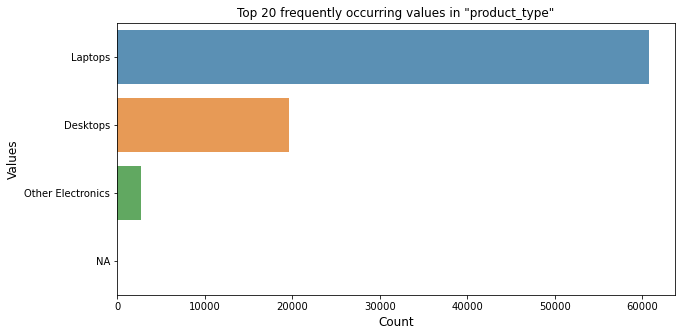

```python
plot_top_n("product_type")
```

### Top contact types

```
VOICE      58008
CHAT       12005
Voice      11977
EMAIL       1080
Unknown       93
NA             9
Name: contact_type, dtype: int64
```

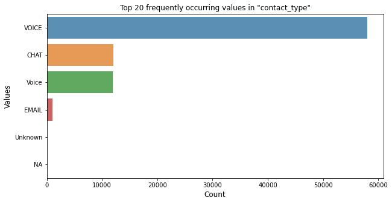

```python
plot_top_n("contact_type")
```

- Most queries are received through voice
- Data issue: VOICE and Voice need to be combined

```
VOICE      69985
CHAT       12005
EMAIL       1080
UNKNOWN       93
NA             9
Name: contact_type, dtype: int64
```

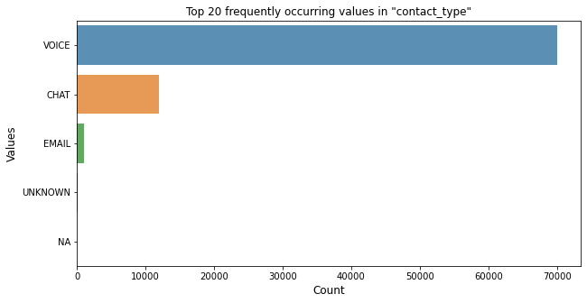

```python
explore_data["contact_type"] = explore_data["contact_type"].apply(lambda x: str(x).upper())
plot_top_n("contact_type")
```

### Top issue types

```
System Board Components                  10856
Fee Based Support                         8486
Operating System                          8092
Hard Drive                                7085
Audio, Video, Speakers, TV Tuner          7020
Input Device / Webcam                     4793
Power Subsystem / Cables / AC Adapter     4299
Contract or Service Issue                 3351
Information Status                        2582
Mechanical Chassis / Rack                 2514
Name: issue_type, dtype: int64
```

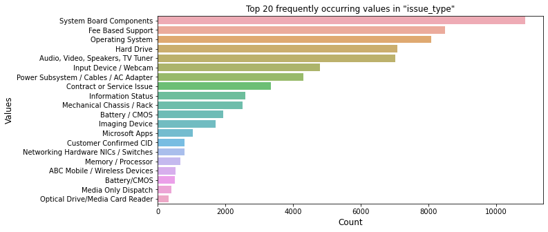

```python
plot_top_n("issue_type")
```

##### We need to take issue type distributions from the new columns we created.

```
issue_systemboardcomponents              10856
issue_feebasedsupport                     8486
issue_operatingsystem                     8092
issue_audio                               7108
issue_harddrive                           7085
issue_speakers                            7020
issue_tvtuner                             7020
issue_video                               7020
issue_inputdevice/webcam                  4793
issue_powersubsystem/cables/acadapter     4299
dtype: int64
```

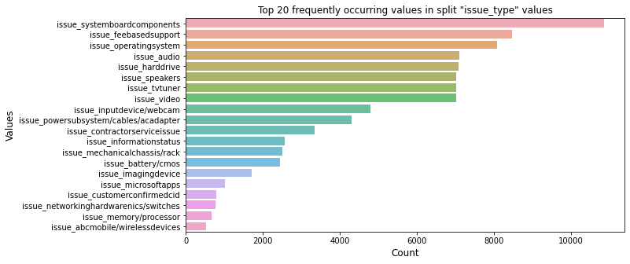

```python
plot_top_n_from_split("issue_type", explore_data=explore_data)
```

Issues appearing in top values changed a bit. Audio, speakers, TV tuners have their own place in top values.

### Top topic categories

```
NA                    27480
Booting               12731
LCD/Monitor            4497
Call Logs              3996
General Queries        3489
Hard Drive             2977
System Performance     2875
Internet/Wireless      2583
Keyboard               2228
Battery                2049
Name: topic_category, dtype: int64
```

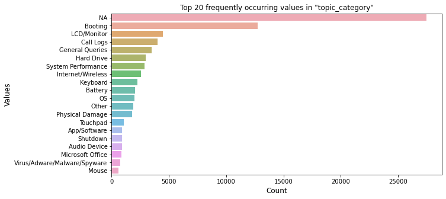

```python
plot_top_n("topic_category")
```

### Distribution of repair types

```
Hard    49463
Soft    33709
Name: repair_type, dtype: int64
```

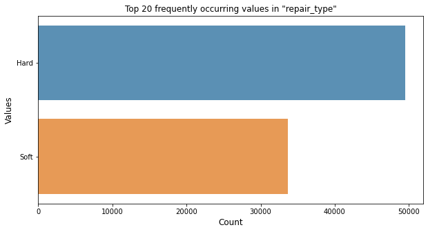

```python
plot_top_n("repair_type")
```

### Distribution of parts sent

```
0    37818
1    20498
2    11474
3     7199
4     3213
5     1527
6      660
7      338
8      197
9       85
Name: parts_ct, dtype: int64
```

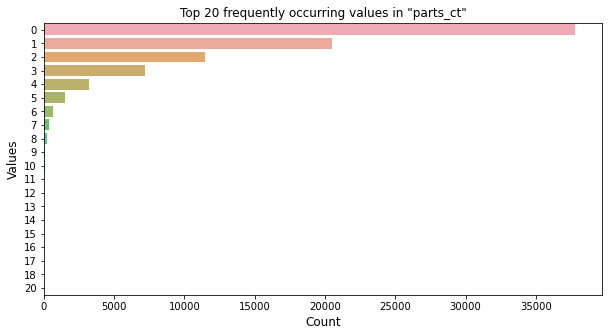

```python
plot_top_n("parts_ct")
```

### Top parts sent

```
Hard Drive                      3750
Motherboard, Documentation      3626
LCD Panel                       2498
Keyboard                        2465
Motherboard                     1867
Chassis                         1756
Battery (Notebook)              1097
Miscellaneous, Hard Drive       1087
Miscellaneous(2)                 809
Hard Drive, Documentation(2)     773
Name: parts_sent, dtype: int64
```

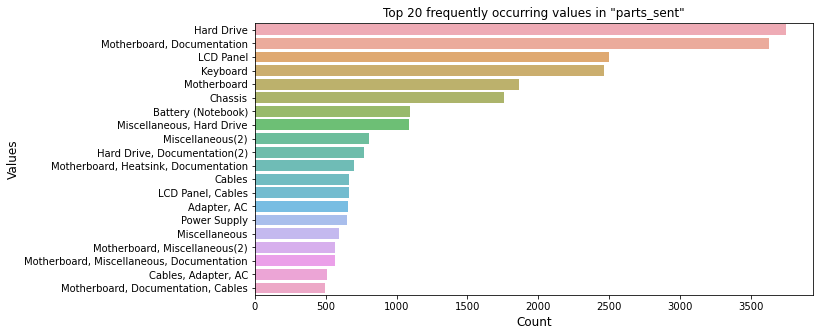

```python
plot_top_n("parts_sent")
```

#### We need to take top values from the new columns we created for each part sent.

```
ps_miscellaneous        15041
ps_motherboard          14665
ps_documentation        10742
ps_chassis              10466
ps_harddrive             7991
ps_lcdpanel              7057
ps_cables                6590
ps_keyboard              4372
ps_heatsink              2763
ps_battery(notebook)     2574
dtype: int64
```

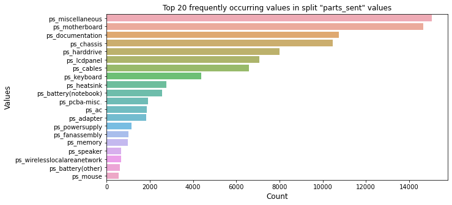

```python
plot_top_n_from_split("parts_sent")
```

The top parts sent changed. Motherboard, documentation and chassis are above hard drive.

### Top parts sent on additional visits

```
Motherboard, Documentation       902
Motherboard                      553
LCD Panel                        541
Chassis                          498
Hard Drive                       438
Keyboard                         405
Cables                           267
Miscellaneous(2)                 222
Motherboard, Miscellaneous(2)    186
Battery (Notebook)               176
Name: repeat_parts_sent, dtype: int64
```

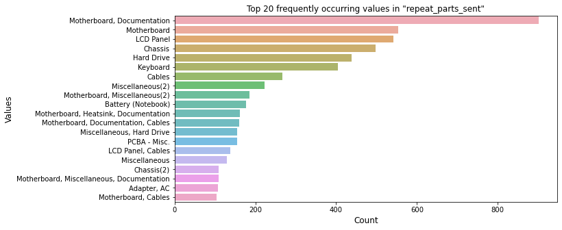

```python
plot_top_n("repeat_parts_sent")
```

##### Again, we need to take top values from the new columns we created for each part sent.

```
rps_motherboard      4470
rps_miscellaneous    3744
rps_chassis          3634
rps_documentation    2875
rps_cables           2228
rps_lcdpanel         1656
rps_harddrive        1337
rps_keyboard         1064
rps_pcba-misc.        755
rps_heatsink          730
dtype: int64
```

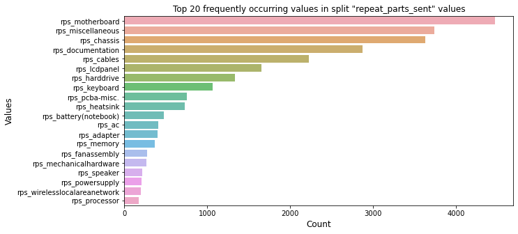

```python
plot_top_n_from_split("repeat_parts_sent")
```

### Distribution of additional visits made bu customers

```
0    77004
1     6160
2        6
3        2
Name: repeat_ct, dtype: int64
```

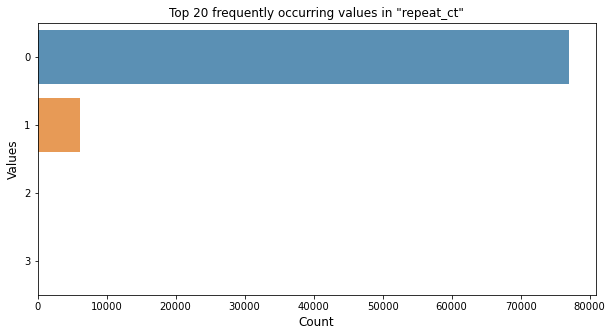

```python
plot_top_n("repeat_ct")
```

### Distribution of agent tenure in days

```
1018.0    11977
686.0      1775
305.0      1556
840.0      1305
676.0      1164
720.0      1061
695.0      1024
463.0       961
781.0       894
298.0       791
Name: agent_tenure_indays, dtype: int64
```

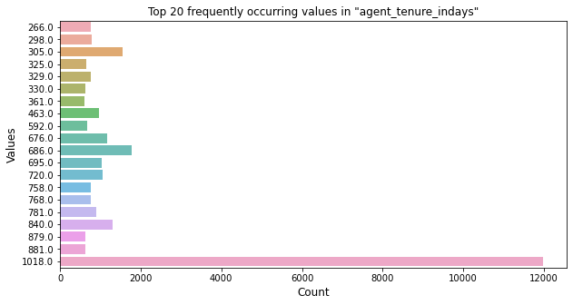

```python
plot_top_n("agent_tenure_indays")
```

### Distribution of issues with manager's involvement

```
0    82147
1     1025
Name: contact_manager_flg, dtype: int64
```

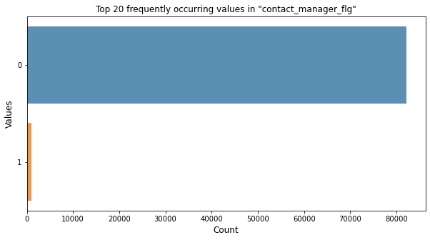

```python
plot_top_n("contact_manager_flg")
```

### Distribution of agents' compliance with diagnostics

```
Not_USED             56123
Effective_Usage      18939
InEffective_Usage     6022
Not_Considered        2088
Name: diagnostics, dtype: int64
```

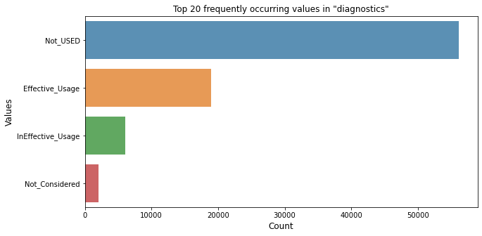

```python
plot_top_n("diagnostics")
```

### Distribution of regions

```
Hogwarts        58171
Middle Earth    20118
Milky Way        4880
NA                  3
Name: region, dtype: int64
```

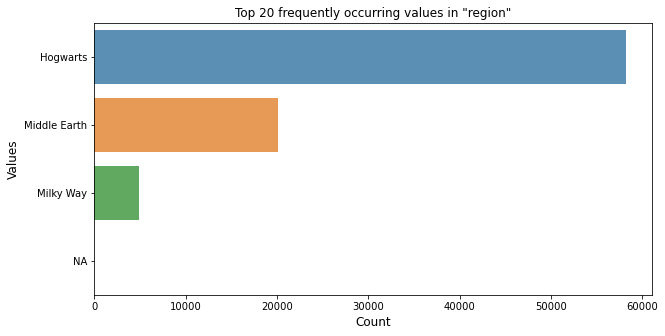

```python
plot_top_n("region")
```

### 2.4 Derive new features

Derive new features like warranty duration, weeks between manufacturing week and contract strat week, weeks between manufacturing and customers contacting, weeks between contract start and customers contacting, and so on...

```python
explore_data["mnfture_yr"] = explore_data["mnfture_wk"].apply(lambda x: str(x)[:4]).astype(int)
explore_data["mnfture_wkno"] = explore_data["mnfture_wk"].apply(lambda x: str(x)[4:]).astype(int)

explore_data["contact_yr"] = explore_data["contact_wk"].apply(lambda x: str(x)[:4]).astype(int)
explore_data["contact_wkno"] = explore_data["contact_wk"].apply(lambda x: str(x)[4:]).astype(int)

explore_data["contract_st_yr"] = explore_data["contract_st"].apply(lambda x: str(x)[:4]).astype(int)
explore_data["contract_st_wkno"] = explore_data["contract_st"].apply(lambda x: str(x)[4:]).astype(int)

explore_data["contract_end_yr"] = explore_data["contract_end"].apply(lambda x: str(x)[:4]).astype(int)
explore_data["contract_end_wkno"] = explore_data["contract_end"].apply(lambda x: str(x)[4:]).astype(int)

explore_data["contract_duration_wks"] = ((explore_data["contract_end_yr"] - explore_data["contract_st_yr"])*(365/7)) \
                                        + explore_data["contract_end_wkno"] - explore_data["contract_st_wkno"]

explore_data["contact_from_mnfture"] = ((explore_data["contact_yr"] - explore_data["mnfture_yr"])*(365/7)) \
                                        + explore_data["contact_wkno"] - explore_data["mnfture_wkno"]

explore_data["contact_from_contract_st"] = ((explore_data["contact_yr"] - explore_data["contract_st_yr"])*(365/7)) \
                                        + explore_data["contact_wkno"] - explore_data["contract_st_wkno"]

explore_data["contact_from_contract_end"] = ((explore_data["contact_yr"] - explore_data["contract_end_yr"])*(365/7)) \
                                        + explore_data["contact_wkno"] - explore_data["contract_end_wkno"]

explore_data["contract_st_from_mnfture"] = ((explore_data["contract_st_yr"] - explore_data["mnfture_yr"])*(365/7)) \
                                        + explore_data["contract_st_wkno"] - explore_data["mnfture_wkno"]

explore_data["contract_end_from_mnfture"] = ((explore_data["contract_end_yr"] - explore_data["mnfture_yr"])*(365/7)) \
                                        + explore_data["contract_end_wkno"] - explore_data["mnfture_wkno"]

explore_data["repeat_parts_ct"] = explore_data[created_value_counts["repeat_parts_sent"]].sum(axis=1)

explore_data.head()
```

|  | asst_id | product_type | mnfture_wk | contract_st | contract_end | contact_wk | contact_type | issue_type | topic_category | parts_sent | ... | contract_st_wkno | contract_end_yr | contract_end_wkno | contract_duration_wks | contact_from_mnfture | contact_from_contract_st | contact_from_contract_end | contract_st_from_mnfture | contract_end_from_mnfture | repeat_parts_ct |
| --- | --- | --- | --- | --- | --- | --- | --- | --- | --- | --- | --- | --- | --- | --- | --- | --- | --- | --- | --- | --- | --- |
| 0 | 0 | Laptops | 201726 | 201726 | 202125 | 201840 | VOICE | NaN | NA | Hard Drive, Documentation(2) | ... | 26 | 2021 | 25 | 207.571429 | 66.142857 | 66.142857 | -141.428571 | 0.0 | 207.571429 | 0 |
| 1 | 1 | Laptops | 201650 | 201650 | 201949 | 201840 | VOICE | NaN | NA | Speaker, Chassis | ... | 50 | 2019 | 49 | 155.428571 | 94.285714 | 94.285714 | -61.142857 | 0.0 | 155.428571 | 0 |
| 2 | 2 | Laptops | 201821 | 201821 | 202222 | 201840 | VOICE | NaN | NA | Cables | ... | 21 | 2022 | 22 | 209.571429 | 19.000000 | 19.000000 | -190.571429 | 0.0 | 209.571429 | 6 |
| 3 | 3 | Laptops | 201608 | 201608 | 201908 | 201840 | VOICE | Hard Drive | Booting | Hard Drive | ... | 8 | 2019 | 8 | 156.428571 | 136.285714 | 136.285714 | -20.142857 | 0.0 | 156.428571 | 0 |
| 4 | 4 | Laptops | 201732 | 201732 | 202032 | 201840 | VOICE | NaN | NA | Battery (Notebook) | ... | 32 | 2020 | 32 | 156.428571 | 60.142857 | 60.142857 | -96.285714 | 0.0 | 156.428571 | 0 |

5 rows × 222 columns

### Distribution of number of parts sent on additional visits

```
0    72061
1     4108
2     2860
3     2025
4     1094
5      508
6      234
7      133
8       70
9       29
Name: repeat_parts_ct, dtype: int64
```

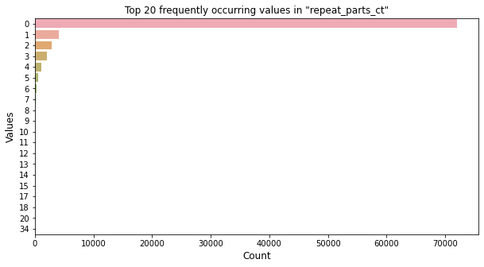

```python
plot_top_n("repeat_parts_ct")
```

### Distribution of newly created derived columns

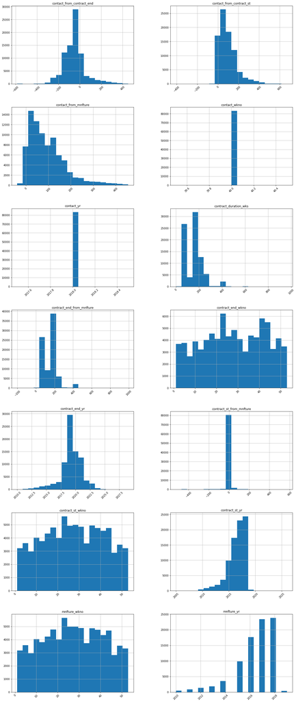

```python
hist_columns = [
    "mnfture_yr",
    "contact_yr",
    "contract_st_yr",
    "contract_end_yr",
    "mnfture_wkno",
    "contact_wkno",
    "contract_st_wkno",
    "contract_end_wkno",
    "contract_duration_wks",
    "contact_from_mnfture",
    "contact_from_contract_st",
    "contact_from_contract_end",
    "contract_st_from_mnfture",
    "contract_end_from_mnfture"
]

explore_data[hist_columns].hist(figsize=(20,50), layout=((len(hist_columns)-1)//2+1, 2), bins=20, xrot=45)
plt.show()
```

- All support requests are from year 2018 week no. 40
- Most of the assets in the dataset are manufactured post 2015
- Most queries are within 200 weeks of manufacturing, with a peak in first 100 weeks
- Most queries are placed within 200 weeks from the warranty starts
- Most queries are within the warranty period, with some queries coming up to 400 weeks after warranty ends
- There are some manufacture dates that are after the contact dates
- Most contracts last for 100 or 200 weeks; roughly 2 or 4 years
- Most warranties start right near the manufacturing time, and end within 100 - 200 weeks from manufacturing
- Most assets are manufactured in the middle of the year
- Most warranties also start in the middle of the year

## 3. Data analysis

### 3.1 Understanding service consumption

This data can answer several questions related to the consumption of the service. These questions would help in predicting the demand for service and its type.

- Do customers owning different types of assets tend to contact in different times of the year? (all queries are from the same week)
- Do repeat counts vary by contact types?
- Does number of parts sent vary by contact types?
- Does number of parts sent vary by asset types?
- Do customers owning different types of assets tend to use different contact media?
- Do issue types vary across different contact media?
- Do topic categories vary across contact types?

### Understanding how number of parts sent vary across different issue attributes

Purpose: to understand if certain areas have a high number of parts sent, to prepare better for handling future issues.

### Question: Does number of parts sent vary by contact types?

```
Distribution of "parts_ct" over "contact_type" values
```

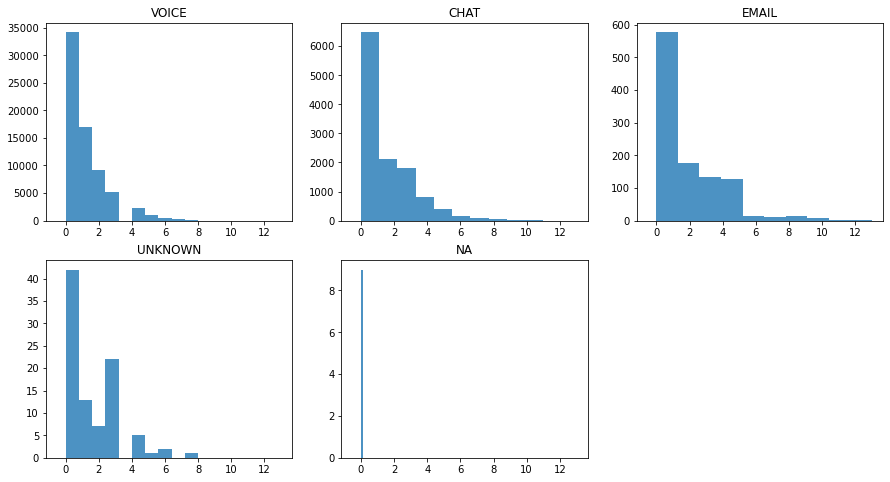

```python
plot_distribution("contact_type", "parts_ct")
```

**Note:** These distributions are mostly Levy Stable distributions and we should be doing t-test for Levy Stable distribution. But I am performing a normal t-tests for time being.

```python
do_t_test("contact_type", 'parts_ct', [('VOICE', 'CHAT'), ('VOICE', 'EMAIL'), ('CHAT', 'EMAIL')])
```

```
T-test for difference in mean 'parts_ct' across 'VOICE' and 'CHAT' in contact_type
Mean for ('VOICE'):, 2.3314361601214193      Mean for ('CHAT'):, 2.3926453143534996
  t = -1.396897525299863
  p = 0.1624889570600012
✘ No significant difference
_____


T-test for difference in mean 'parts_ct' across 'VOICE' and 'EMAIL' in contact_type
Mean for ('VOICE'):, 2.3314361601214193      Mean for ('EMAIL'):, 2.991111111111111
  t = -5.8510341044416645
  p = 5.167569510602931e-09
✔ Significant difference
_____


T-test for difference in mean 'parts_ct' across 'CHAT' and 'EMAIL' in contact_type
Mean for ('CHAT'):, 2.3926453143534996      Mean for ('EMAIL'):, 2.991111111111111
  t = -4.825811200412091
  p = 1.5050771071264036e-06
✔ Significant difference
_____
```

### Question: Does number of parts sent vary by product types?

```
Distribution of "parts_ct" over "product_type" values
```

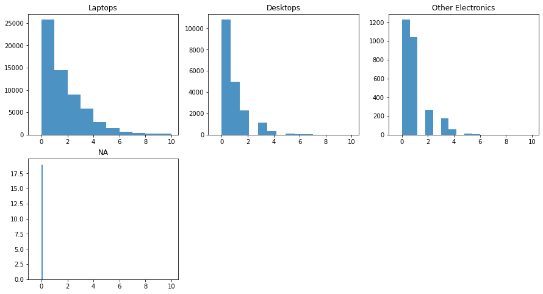

```python
plot_distribution("product_type", "parts_ct")
```

More parts are sent for issues related to laptops compared to desktops and others.

```python
do_t_test("product_type", 'parts_ct', [('Laptops', 'Desktops'), ('Laptops', 'Other Electronics'),
                                       ('Desktops', 'Other Electronics')])
```

```
T-test for difference in mean 'parts_ct' across 'Laptops' and 'Desktops' in product_type
Mean for ('Laptops'):, 2.496714615521222      Mean for ('Desktops'):, 1.8973988439306357
  t = 12.331970301706388
  p = 1.3883386489139986e-34
✔ Significant difference
_____


T-test for difference in mean 'parts_ct' across 'Laptops' and 'Other Electronics' in product_type
Mean for ('Laptops'):, 2.496714615521222      Mean for ('Other Electronics'):, 1.9222222222222223
  t = 4.443502509996598
  p = 9.015027753695981e-06
✔ Significant difference
_____


T-test for difference in mean 'parts_ct' across 'Desktops' and 'Other Electronics' in product_type
Mean for ('Desktops'):, 1.8973988439306357      Mean for ('Other Electronics'):, 1.9222222222222223
  t = -0.2789436915956921
  p = 0.7803249630443666
✘ No significant difference
_____
```

### Question: Does number of parts sent vary with agents' compliance with diagnostic usage?

```
Distribution of "parts_ct" over "diagnostics" values
```

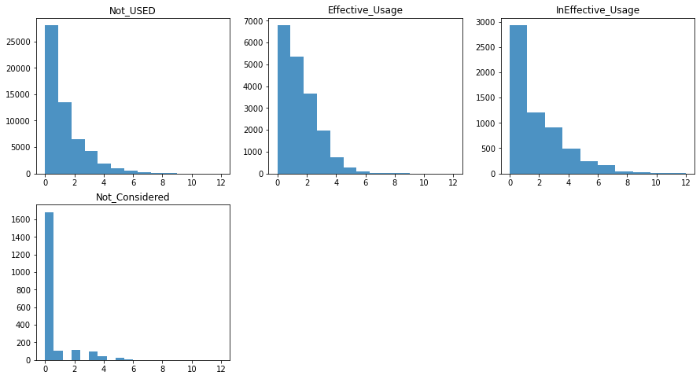

```python
plot_distribution("diagnostics", "parts_ct")
```

```python
do_t_test("diagnostics", 'parts_ct', [('Not_USED', 'Effective_Usage'), ('InEffective_Usage', 'Effective_Usage'),
                                      ('Not_USED', 'InEffective_Usage')])
```

```
T-test for difference in mean 'parts_ct' across 'Not_USED' and 'Effective_Usage' in diagnostics
Mean for ('Not_USED'):, 2.5348119034250423      Mean for ('Effective_Usage'):, 2.0441176470588234
  t = 11.800816666216067
  p = 8.578980765292045e-32
✔ Significant difference
_____


T-test for difference in mean 'parts_ct' across 'InEffective_Usage' and 'Effective_Usage' in diagnostics
Mean for ('InEffective_Usage'):, 2.5559883154819865      Mean for ('Effective_Usage'):, 2.0441176470588234
  t = 10.42357377106209
  p = 4.446652086986402e-25
✔ Significant difference
_____


T-test for difference in mean 'parts_ct' across 'Not_USED' and 'InEffective_Usage' in diagnostics
Mean for ('Not_USED'):, 2.5348119034250423      Mean for ('InEffective_Usage'):, 2.5559883154819865
  t = -0.32722737892536063
  p = 0.7435108462675324
✘ No significant difference
_____
```

### Understanding agent performance

### Question: Does the need for agents to involve managers vary with agents' tenure?

```
Distribution of "agent_tenure_indays" over "contact_manager_flg" values
```

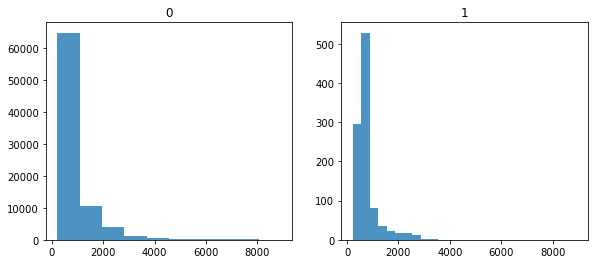

```python
plot_distribution("contact_manager_flg", "agent_tenure_indays")
```

It seems like the issues that need managers are handled by agents with lower tenures.

```python
do_t_test("contact_manager_flg", "agent_tenure_indays", [(0, 1)])
```

```
T-test for difference in mean 'agent_tenure_indays' across '0' and '1' in contact_manager_flg
Mean for ('0'):, 1012.6187553525549      Mean for ('1'):, 917.0899470899471
  t = 1.2297118640520337
  p = 0.21884524244723672
✘ No significant difference
_____
```

The test however, says that the distribution of agents' tenure is no different in the two distributions. That means, agent's tenure does not determine the need to involve manager.

### Question: Does the need for agents to involve managers vary by contact types?

```
Distribution of "contact_manager_flg" over "contact_type" values
```

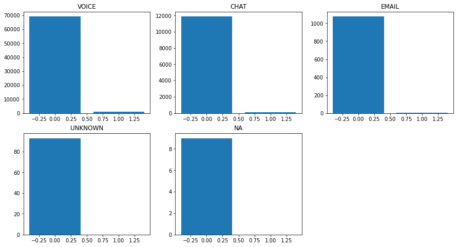

```python
plot_cat_distribution("contact_type", "contact_manager_flg")
```

The distributions seem similar, but we should verify that with a chi-squared test.

```python
do_chi_sq("contact_type", "contact_manager_flg")
```

```
Actual:
             0    1
VOICE    69093  892
CHAT     11877  128
EMAIL     1075    5
UNKNOWN     93    0
NA           9    0

Expected:
             0    1
VOICE    69123  862
CHAT     11857  148
EMAIL     1067   13
UNKNOWN     92    1
NA           9    0

Degrees of freedom: 4
probability=0.975, critical=11.143, stat=10.271
✘ Not different than expected (fail to reject H0)
significance=0.025, p=0.036
✘ Not different than expected (fail to reject H0)
_____
```

The test tells us that the need for agents to involve managers does not vary by contact types. This implies that problems reported via any contact medium are equially difficult for agents.

### Question: Does the need for agents to involve managers vary by asset types?

```
Distribution of "contact_manager_flg" over "product_type" values
```

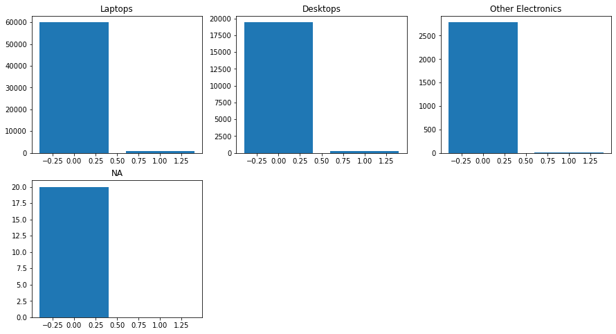

```python
plot_cat_distribution("product_type", "contact_manager_flg")
```

The distributions again look similar. Let's verify with a chi-squared test.

```python
do_chi_sq("product_type", "contact_manager_flg")
```

```
Actual:
                       0    1
Laptops            59938  754
Desktops           19406  266
Other Electronics   2783    5
NA                    20    0

Expected:
                       0    1
Laptops            59944  748
Desktops           19430  242
Other Electronics   2754   34
NA                    20    0

Degrees of freedom: 3
probability=0.975, critical=9.348, stat=28.018
✔ Different than expected (reject H0)
significance=0.025, p=0.000
✔ Different than expected (reject H0)
_____
```

When compared all four types together, the distributions are different. That means the need to involve managers is different for different asset types, and is not by random chance. But we should compare the contact types in pairs for more clarity.

```python
do_chi_sq("product_type", "contact_manager_flg", valgroups=[["Laptops", "Desktops"], ["Laptops", "Other Electronics"],
                                                     ["Desktops", "Other Electronics"]])
```

```
Chi-squared test for counts of 'contact_manager_flg' across  ['Laptops', 'Desktops']  in product_type

Actual:
              0    1
Laptops   59938  754
Desktops  19406  266

Expected:
              0    1
Laptops   59922  770
Desktops  19422  250

Degrees of freedom: 1
probability=0.975, critical=5.024, stat=1.430
✘ Not different than expected (fail to reject H0)
significance=0.025, p=0.232
✘ Not different than expected (fail to reject H0)
_____


Chi-squared test for counts of 'contact_manager_flg' across  ['Laptops', 'Other Electronics']  in product_type

Actual:
                       0    1
Laptops            59938  754
Other Electronics   2783    5

Expected:
                       0    1
Laptops            59966  726
Other Electronics   2755   33

Degrees of freedom: 1
probability=0.975, critical=5.024, stat=25.496
✔ Different than expected (reject H0)
significance=0.025, p=0.000
✔ Different than expected (reject H0)
_____


Chi-squared test for counts of 'contact_manager_flg' across  ['Desktops', 'Other Electronics']  in product_type

Actual:
                       0    1
Desktops           19406  266
Other Electronics   2783    5

Expected:
                       0    1
Desktops           19435  237
Other Electronics   2754   34

Degrees of freedom: 1
probability=0.975, critical=5.024, stat=28.179
✔ Different than expected (reject H0)
significance=0.025, p=0.000
✔ Different than expected (reject H0)
_____
```

The detailed test tells us that the need for agents to involve managers is not different for laptops and desktops. But it is different for other electronics.

### Question: Does the need for agents to involve managers vary by issue type?

To do this, we will need to count the issues across the new columns created for different issue types. This would need some efforts. Hence, keeping this test for later phase.

### Question: Does the need for agents to involve managers vary by repair type?

```
Distribution of "repair_type" over "contact_manager_flg" values
```

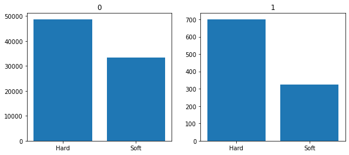

```python
plot_cat_distribution("contact_manager_flg", "repair_type")
```

It seems like the issues that need managers to be involved have high proportion of hard repairs.

```python
do_chi_sq("contact_manager_flg", "repair_type")
```

```
Actual:
    Hard   Soft
0  48762  33385
1    701    324

Expected:
    Hard   Soft
0  48853  33294
1    610    415

Degrees of freedom: 1
probability=0.975, critical=5.024, stat=34.255
✔ Different than expected (reject H0)
significance=0.025, p=0.000
✔ Different than expected (reject H0)
_____
```

The test verifies that the distributions are different. Hence, hard repairs have higher chances of needing to involve managers.

### Understanging repair types

### Question: Does the repair type requirement vary by asset types?

```
Distribution of "repair_type" over "product_type" values
```

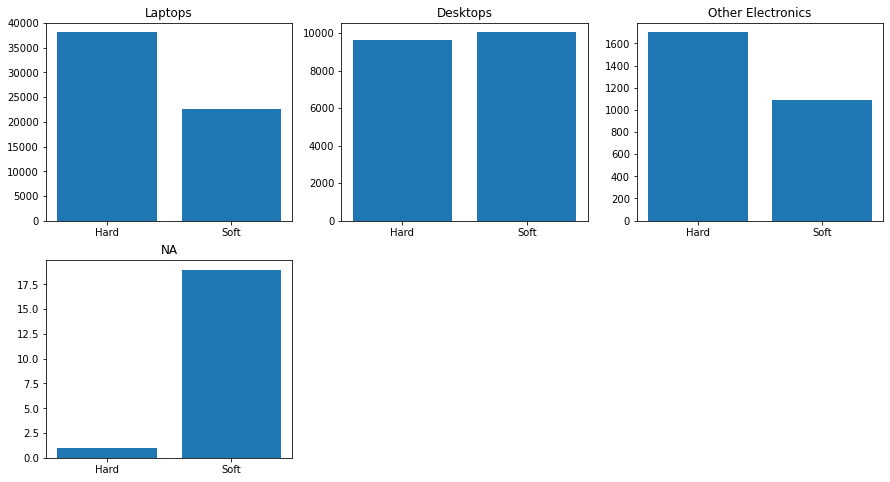

```python
plot_cat_distribution("product_type", "repair_type")
```

It seems like desktops have more soft repairs and laptops and other electronics have a higher proportion of hard repairs.

```python
do_chi_sq("product_type", "repair_type", valgroups=[["Laptops", "Desktops"], ["Laptops", "Other Electronics"],
                                                     ["Desktops", "Other Electronics"]])
```

```
Chi-squared test for counts of 'repair_type' across  ['Laptops', 'Desktops']  in product_type

Actual:
           Hard   Soft
Laptops   38134  22558
Desktops   9628  10044

Expected:
           Hard   Soft
Laptops   36071  24621
Desktops  11691   7981

Degrees of freedom: 1
probability=0.975, critical=5.024, stat=1188.716
✔ Different than expected (reject H0)
significance=0.025, p=0.000
✔ Different than expected (reject H0)
_____


Chi-squared test for counts of 'repair_type' across  ['Laptops', 'Other Electronics']  in product_type

Actual:
                    Hard   Soft
Laptops            38134  22558
Other Electronics   1700   1088

Expected:
                    Hard   Soft
Laptops            38085  22607
Other Electronics   1749   1039

Degrees of freedom: 1
probability=0.975, critical=5.024, stat=3.930
✘ Not different than expected (fail to reject H0)
significance=0.025, p=0.047
✘ Not different than expected (fail to reject H0)
_____


Chi-squared test for counts of 'repair_type' across  ['Desktops', 'Other Electronics']  in product_type

Actual:
                   Hard   Soft
Desktops           9628  10044
Other Electronics  1700   1088

Expected:
                   Hard  Soft
Desktops           9922  9750
Other Electronics  1406  1382

Degrees of freedom: 1
probability=0.975, critical=5.024, stat=141.439
✔ Different than expected (reject H0)
significance=0.025, p=0.000
✔ Different than expected (reject H0)
_____
```

The chi-squared tests verify our hypothesis. Desktops have more probability of resolving the issue by soft repairs. Laptops and other electronics have higher probability of hard repairs needed.

### Question: Do the repair types vary agents' compliance with diagnostics?

```
Distribution of "repair_type" over "diagnostics" values
```

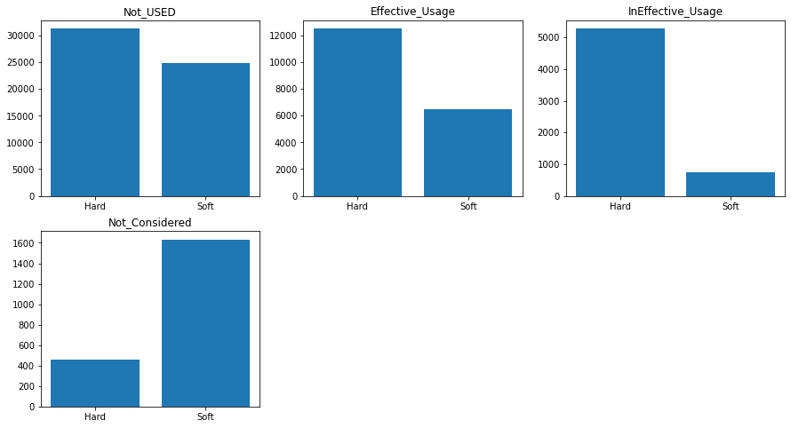

```python
plot_cat_distribution("diagnostics", "repair_type")
```

Agents who have compliance 'Not_Considered' have more soft queries. Other three compliances have higher number of hard queries. 'InEffective_Usage' has the highest proportin of hard queries.

```python
do_chi_sq("diagnostics", "repair_type", valgroups=[
    ["Not_USED", "Effective_Usage"], ["Not_USED", "InEffective_Usage"], ["Not_USED", "Not_Considered"],
    ["Effective_Usage", "InEffective_Usage"], ["Effective_Usage", "Not_Considered"],
    ["InEffective_Usage", "Not_Considered"],
])
```

```
Chi-squared test for counts of 'repair_type' across  ['Not_USED', 'Effective_Usage']  in diagnostics

Actual:
                  Hard   Soft
Not_USED         31254  24869
Effective_Usage  12481   6458

Expected:
                  Hard   Soft
Not_USED         32700  23423
Effective_Usage  11035   7904

Degrees of freedom: 1
probability=0.975, critical=5.024, stat=607.361
✔ Different than expected (reject H0)
significance=0.025, p=0.000
✔ Different than expected (reject H0)
_____


Chi-squared test for counts of 'repair_type' across  ['Not_USED', 'InEffective_Usage']  in diagnostics

Actual:
                    Hard   Soft
Not_USED           31254  24869
InEffective_Usage   5274    748

Expected:
                    Hard   Soft
Not_USED           32988  23135
InEffective_Usage   3540   2482

Degrees of freedom: 1
probability=0.975, critical=5.024, stat=2282.736
✔ Different than expected (reject H0)
significance=0.025, p=0.000
✔ Different than expected (reject H0)
_____


```

[output cut: 63 more lines]

```
                   Hard  Soft
InEffective_Usage  5274   748
Not_Considered      454  1634

Expected:
                   Hard  Soft
InEffective_Usage  4253  1769
Not_Considered     1475   613

Degrees of freedom: 1
probability=0.975, critical=5.024, stat=3239.431
✔ Different than expected (reject H0)
significance=0.025, p=0.000
✔ Different than expected (reject H0)
_____
```

All six chi-squared tests say that the four distributions are different from each other. That means, the probabilities of hard and soft repairs vary with agent's compliance with diagnostics.

### Understanding product types

### Question: Do product types reported in issues vary by region?

```
Distribution of "region" over "product_type" values
```

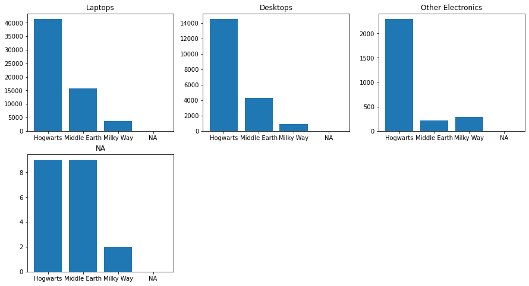

```python
plot_cat_distribution("product_type", "region")
```

It seems like Hogwarts has the highest share in the issues. But Middle Earth has more issues related to laptops and desktops compared to Milky Way, which has more issues related to other electronics.

```python
do_chi_sq("product_type", "region", valgroups=[["Laptops", "Desktops"], ["Laptops", "Other Electronics"],
                                               ["Desktops", "Other Electronics"]],
         cols=["Hogwarts", "Middle Earth", "Milky Way"])
```

```
Chi-squared test for counts of 'region' across  ['Laptops', 'Desktops']  in product_type

Actual:
          Hogwarts  Middle Earth  Milky Way
Laptops      41339         15618       3732
Desktops     14531          4277        864

Expected:
         Hogwarts Middle Earth Milky Way
Laptops     42193        15025      3471
Desktops    13677         4870      1125

Degrees of freedom: 2
probability=0.975, critical=7.378, stat=246.555
✔ Different than expected (reject H0)
significance=0.025, p=0.000
✔ Different than expected (reject H0)
_____


Chi-squared test for counts of 'region' across  ['Laptops', 'Other Electronics']  in product_type

Actual:
                   Hogwarts  Middle Earth  Milky Way
Laptops               41339         15618       3732
Other Electronics      2292           214        282

Expected:
                  Hogwarts Middle Earth Milky Way
Laptops              41715        15137      3838
Other Electronics     1916          695       176

Degrees of freedom: 2
probability=0.975, critical=7.378, stat=491.839
✔ Different than expected (reject H0)
significance=0.025, p=0.000
✔ Different than expected (reject H0)
_____


Chi-squared test for counts of 'region' across  ['Desktops', 'Other Electronics']  in product_type

Actual:
                   Hogwarts  Middle Earth  Milky Way
Desktops              14531          4277        864
Other Electronics      2292           214        282

Expected:
                  Hogwarts Middle Earth Milky Way
Desktops             14735         3934      1004
Other Electronics     2088          557       142

Degrees of freedom: 2
probability=0.975, critical=7.378, stat=421.045
✔ Different than expected (reject H0)
significance=0.025, p=0.000
✔ Different than expected (reject H0)
_____
```

All the distributions are different. That means, there is a variation in product types of issues across regions.

### Understanding agents' compliance

### Question: Does agents' compliance with diagnostics vary with their tenure?

```
Distribution of "agent_tenure_indays" over "diagnostics" values
```

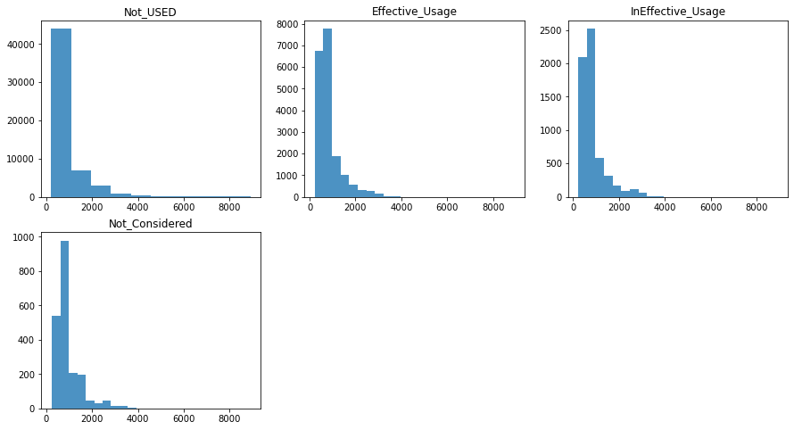

```python
plot_distribution("diagnostics", "agent_tenure_indays")
```

```python
do_t_test("diagnostics", "agent_tenure_indays", valpairs=[
    ["Not_USED", "Effective_Usage"], ["Not_USED", "InEffective_Usage"], ["Not_USED", "Not_Considered"],
    ["Effective_Usage", "InEffective_Usage"], ["Effective_Usage", "Not_Considered"],
    ["InEffective_Usage", "Not_Considered"]
])
```

```
T-test for difference in mean 'agent_tenure_indays' across 'Not_USED' and 'Effective_Usage' in diagnostics
Mean for ('Not_USED'):, 1144.686412128018      Mean for ('Effective_Usage'):, 880.7122416534181
  t = 9.310271314181355
  p = 1.7441764369508846e-20
✔ Significant difference
_____


T-test for difference in mean 'agent_tenure_indays' across 'Not_USED' and 'InEffective_Usage' in diagnostics
Mean for ('Not_USED'):, 1144.686412128018      Mean for ('InEffective_Usage'):, 880.3953261927945
  t = 6.408180112489876
  p = 1.6206858339108888e-10
✔ Significant difference
_____


T-test for difference in mean 'agent_tenure_indays' across 'Not_USED' and 'Not_Considered' in diagnostics
Mean for ('Not_USED'):, 1144.686412128018      Mean for ('Not_Considered'):, 781.4
  t = 2.7476723149658238
  p = 0.006031480973895197
✔ Significant difference
_____


T-test for difference in mean 'agent_tenure_indays' across 'Effective_Usage' and 'InEffective_Usage' in diagnostics
Mean for ('Effective_Usage'):, 880.7122416534181      Mean for ('InEffective_Usage'):, 880.3953261927945
  t = 0.010711286115018308
  p = 0.9914543970029005
✘ No significant difference
_____


T-test for difference in mean 'agent_tenure_indays' across 'Effective_Usage' and 'Not_Considered' in diagnostics
Mean for ('Effective_Usage'):, 880.7122416534181      Mean for ('Not_Considered'):, 781.4
  t = 1.1658116701423833
  p = 0.24379736642657757
✘ No significant difference
_____


T-test for difference in mean 'agent_tenure_indays' across 'InEffective_Usage' and 'Not_Considered' in diagnostics
Mean for ('InEffective_Usage'):, 880.3953261927945      Mean for ('Not_Considered'):, 781.4
  t = 1.170834240971959
  p = 0.24191557485663387
✘ No significant difference
_____
```

Agents who have 'InEffective_Usage', 'Effective_Usage' and 'Not_Considered' have lower average tenure. On the other hand, agents with 'Not_USED' compliance have significantly high tenure.

```
Distribution of "agent_tenure_indays" over "contact_manager_flg" values
```

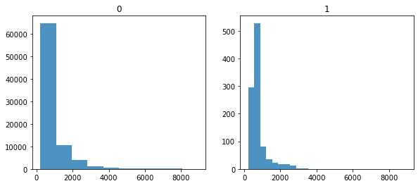

```python
plot_distribution("contact_manager_flg", "agent_tenure_indays")
```

It seems like issues that involve managers are usually handled by agents with less experience. A t-test would further verify that.

```python
do_t_test("contact_manager_flg", 'agent_tenure_indays', [(0, 1)])
```

```
T-test for difference in mean 'agent_tenure_indays' across '0' and '1' in contact_manager_flg
Mean for ('0'):, 1012.6187553525549      Mean for ('1'):, 917.0899470899471
  t = 1.2297118640520337
  p = 0.21884524244723672
✘ No significant difference
_____
```

T-test tells us agents tenure is not significantly different across the need to involve managers. That means agents of all tenures may need managers.